# Coursework Report - Green Study

*N* removed NAs: 5

*N* removed <18: 14

**Correct typo age:** 23

*N* total clean: 149

| Group | *N* | *M*<sub>age</sub> | % green |
| --- | --- | --- | --- |
| Control | 72 | 20.8 | 52.8 |
| Experim | 77 | 20.7 | 33.3 |

| Gender | *N* | *M*<sub>age</sub> | % green |
| --- | --- | --- | --- |
| Female | 72 | 20.8 | 46.3 |
| Male | 52 | 20.9 | 41.7 |
| Other | 25 | 20.4 | 34.7 |

**Main analysis results**

**cleaner:**  
χ<sup>2</sup>(1) = 6.3, *p* = .012

**dishwasher:**  
χ<sup>2</sup>(1) = 1.81, *p* = .178

[interactive chart not shown]

[figure not shown]

[interactive chart not shown]

# Coursework Report - Green Study

Analysing Data, Spring 2020

# Methods

## Participants

Table 1 *Descriptives table of age by condition and gender*

[output not shown]

## Design

It was predicted that activation of social status motives would increase the likelihood of people choosing green (environmentally friendly) products over more luxurious ones.

In this experiment the dependent variable is the product choice. This variable is a factor which has two levels; green and luxury. Each participant was given a choice between a green and a luxury version of a car, cleaner and dishwasher. The product types were similarly priced, though the luxury product was superior in terms of function and luxuriousness, while the green product was obviously environmentally friendly.

Green indicates the participant’s choice of an environmentally friendly (and thus prosocial) product while Luxury indicates the choice of a non-environmentally friendly, luxury product.

The operational hypothesis states that participants in the experimental condition (i.e. those who have read a short story intended to elicit status motives) would be more likely to choose the green version of a product (such as a dishwasher, cleaner or car) over the luxury version than participants in the control condition (who read a short story with no status motive primes.) To test the significance of the results I will be running a Chi-squared statistical test.

# Results

The results show that fewer participants chose the green car, dishwasher and cleaner in the experimental condition than in the control condition. In the experimental condition, more luxury products than green products were chosen while the inverse is true for cars and cleaners, but not dishwashers, in the control condition. In the experiment carried out by Griskeviciou (Griskevicius et al., 2010) , however, the results show the opposite effect. In the control group, all three luxury products were more desirable than their green counterparts, while the experimental condition increased the participants’ likelihood of choosing the green products.

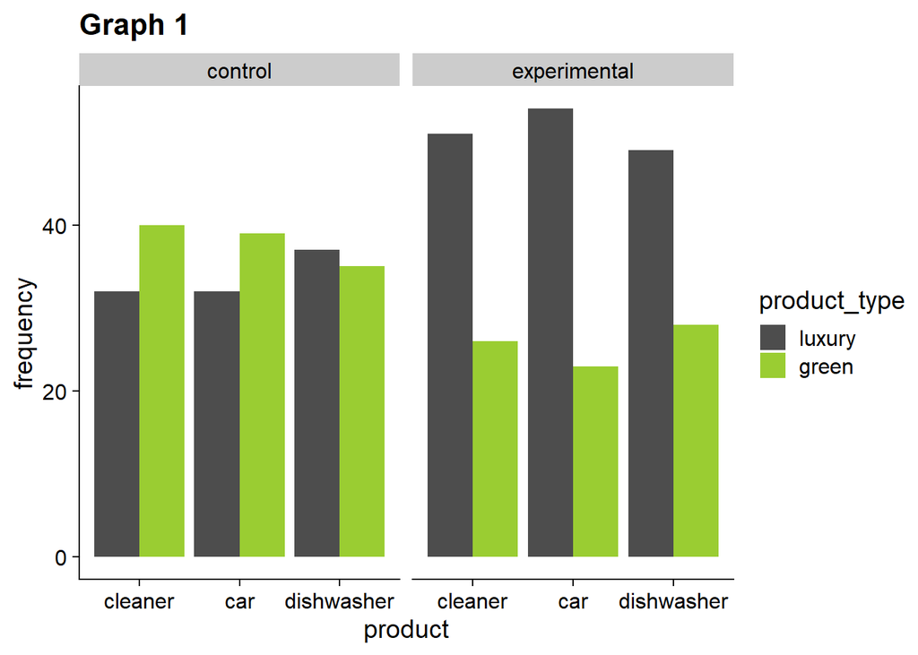

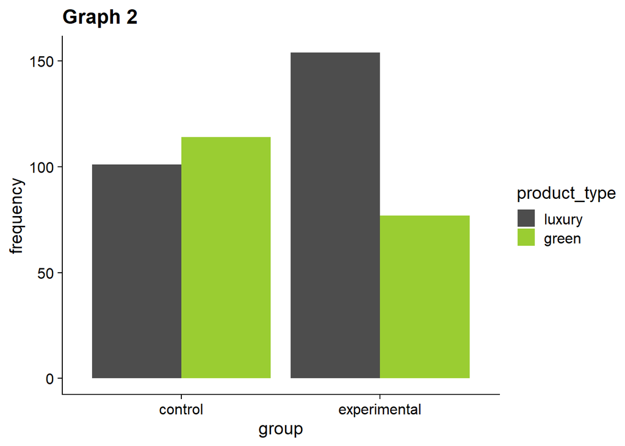

The Chi-squared test shows that the results for the car (p=.003) and cleaner (p=.01 ) are unlikely to have occurred were the null hypothesis true. However, they do not support the alternative hypothesis and seem to suggest that status motives decrease the likelihood of green products being chosen. The results for the dishwasher (p=.18) are not significant and could have occurred under the null hypothesis.

```
##
##  Pearson's Chi-squared test with Yates' continuity correction
##
## data:  freq_tab_car
## X-squared = 9, df = 1, p-value = 0.003
```

```
##
##  Pearson's Chi-squared test with Yates' continuity correction
##
## data:  freq_tab_dishwasher
## X-squared = 2, df = 1, p-value = 0.2
```

```
##
##  Pearson's Chi-squared test with Yates' continuity correction
##
## data:  freq_tab_cleaner
## X-squared = 6, df = 1, p-value = 0.01
```

# Discussion

While this study would require further replication, it suggests that factors other than status motives affect product choice, in this case leading to results opposite to the one in the original experiment. This study supports the hypothesis that inducing status motives increases the likelihood of choosing luxury products over green.

A limiting factor of my experiment is the rather narrow age range of the participants. This limits the ecological validity and renders us unable to generalise the results to the wider population. Future experiments should include larger ranges of participant age to avoid this problem. The fact that this experiment on measures the intent to buy one product or another could also affect the results. Further studies might incorporate the actual spending of money to make the results more applicable to real life situations. Additionally, finding out the nationality or race of the participants, as well as conducting experiments in different countries, would allow us to investigate the effect of culture on status motives and resultant product choice. It would be useful to discover whether all people engage in “competitive altruism”, i.e. alstruistic behaviour, such as buying environmentally friendly products, as a form of “costly signalling” used to increase one’s social status and desirability (Roberts, 1998), (Smith & Bird, n.d.) or whether it is a culture specific phenomenon.

In conclusion, these results support the opposite of the original hypothesis (i.e. that status motives increase the likelihood of green products being chosen), though I would repeat the experiment again to make sure these findings are replicable.

# References

Griskevicius, V., Tybur, J. M., & Van den Bergh, B. (2010). Going green to be seen: Status, reputation, and conspicuous conservation. Journal of Personality and Social Psychology, 98(3), 392–404. https://doi.org/10.1037/a0017346

Roberts, G. (1998). Competitive altruism: From reciprocity to the handicap principle. Proceedings of the Royal Society of London. Series B: Biological Sciences, 265(1394), 427–431. https://doi.org/10.1098/rspb.1998.0312

Smith, E. A., & Bird, R. B. (n.d.). Costly Signaling and Prosocial Behavior. 24.